# PM566 Lab 6 - Text Mining

Author

Chih-Chan Jessica Lan

```r
library(dplyr)
library(ggplot2)
library(tidytext)
library(readr)
library(tidyr)
```

```r
mt_samples <- read_csv("https://raw.githubusercontent.com/USCbiostats/data-science-data/master/00_mtsamples/mtsamples.csv")
```

```
──────────────────────────────────────────────────────── Delimiter: "," chr
(5): description, medical_specialty, sample_name, transcription, keywords dbl
(1): ...1
```

```r
mt_samples <- mt_samples |>
  select(description, medical_specialty, transcription)

head(mt_samples)
```

```
# A tibble: 6 × 3
  description                                    medical_specialty transcription
  <chr>                                          <chr>             <chr>
1 A 23-year-old white female presents with comp… Allergy / Immuno… "SUBJECTIVE:…
2 Consult for laparoscopic gastric bypass.       Bariatrics        "PAST MEDICA…
3 Consult for laparoscopic gastric bypass.       Bariatrics        "HISTORY OF …
4 2-D M-Mode. Doppler.                           Cardiovascular /… "2-D M-MODE:…
5 2-D Echocardiogram                             Cardiovascular /… "1.  The lef…
6 Morbid obesity.  Laparoscopic antecolic anteg… Bariatrics        "PREOPERATIV…
```

# Question1

```r
mt_samples %>%
  count(medical_specialty, sort = TRUE)
```

```
# A tibble: 40 × 2
   medical_specialty                 n
   <chr>                         <int>
 1 Surgery                        1103
 2 Consult - History and Phy.      516
 3 Cardiovascular / Pulmonary      372
 4 Orthopedic                      355
 5 Radiology                       273
 6 General Medicine                259
 7 Gastroenterology                230
 8 Neurology                       223
 9 SOAP / Chart / Progress Notes   166
10 Obstetrics / Gynecology         160
# ℹ 30 more rows
```

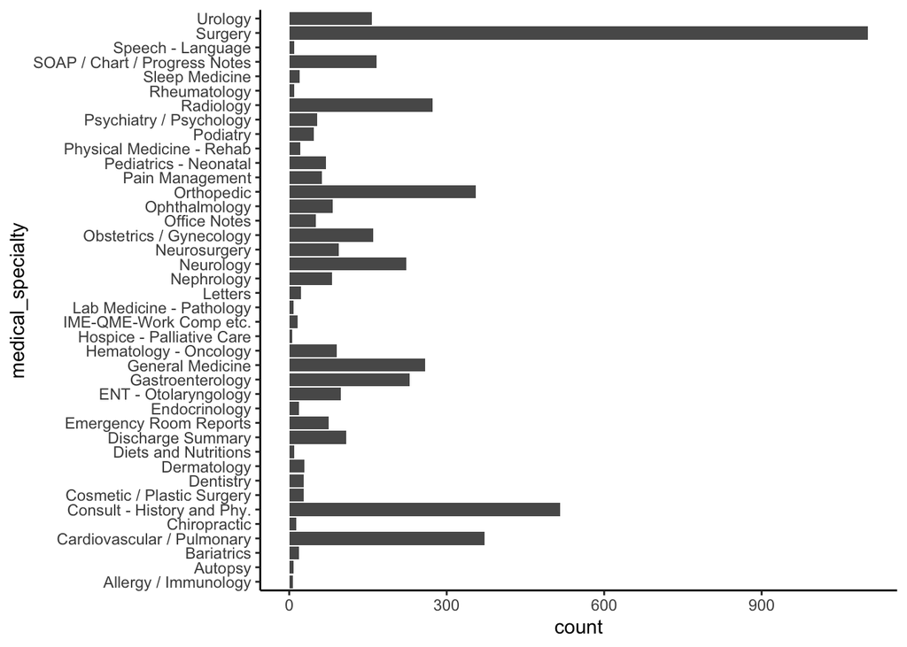

```r
ggplot(data = mt_samples) +
  geom_bar(aes(x = medical_specialty)) +
  coord_flip() +
  theme_classic()
```

Answers: There are 40 specialties in the data. There’s no overlapped between specialties. However, the distribution is not even. Some specialties, such as Surgery and Consultation/History, appear more frequently.

# Question2

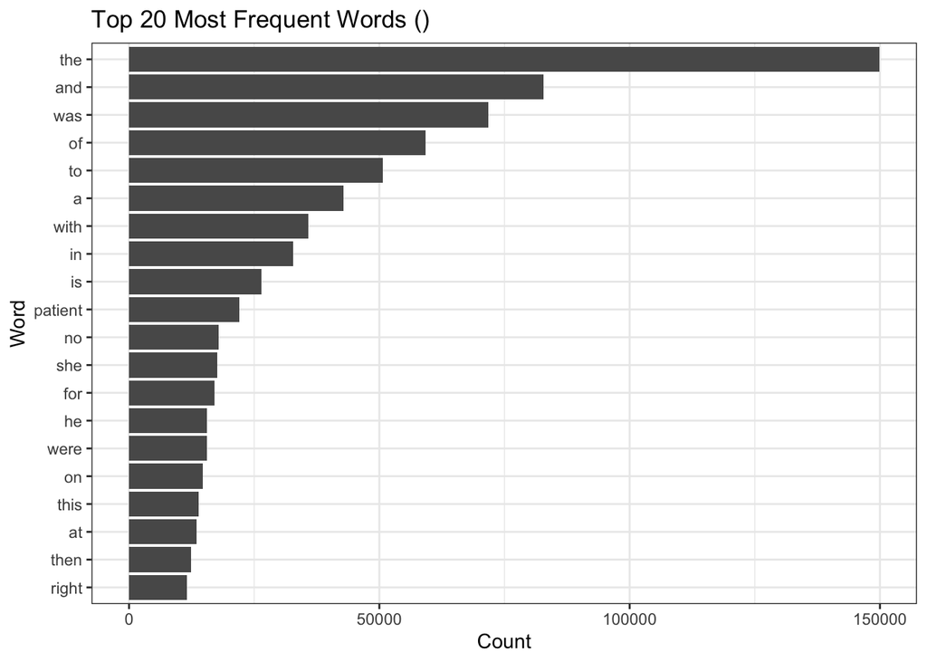

```r
mt_samples %>%
  unnest_tokens(word, transcription) %>%
  count(word, sord = T) %>%
  top_n(20, n) %>%
  ggplot(aes(x = reorder(word, n), y = n)) +
  geom_col() +
  theme_bw() +
  coord_flip() +
  labs(x = "Word", y = "Count", title = "Top 20 Most Frequent Words ()")
```

Answer: From the top 20 words, we can see that most of them are common but non-meaningfull words, such as “the”, “and”, “was” etc. This makes sense because these are the most most frequently used words in English, often referred to as stop words. From a text analysis perspective, these words do no provide useful information on the content. Among the top words graph, only “patient” gives a hint that the data is related to medical records. Overall, we can observe that the most frequently used words do not provide much meaningful information.

# Question3

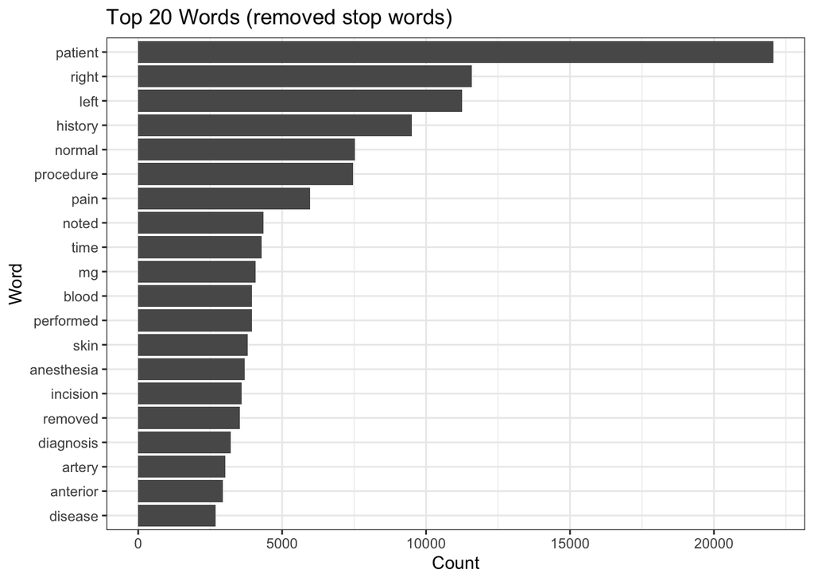

```r
stop_words_update <- stop_words[!stop_words$word %in% c("right", "left"), ]

mt_samples %>%
  unnest_tokens(word, transcription) %>%
  anti_join(stop_words_update, by = "word") %>%
  filter(!grepl("^[0-9]+$", word)) %>%
  count(word, sort = T) %>%
  top_n(20, n) %>%
  ggplot(aes(x = reorder(word, n), y = n)) +
  geom_col() +
  theme_bw() +
  coord_flip() +
  labs(x = "Word", y = "Count", title = "Top 20 Words (removed stop words)")
```

Answer: Since I consider “right” and “left” meaningful in the context of medical records, I kept them instead of removing them as stop words. After removing common stop words, the top frequently used words are now much more related to the medical field. Words such as “patient,” “history,” “procedure,” “pain,” and “left/right” reflect clinical documentation and indicate that the text likely describes patient history, body orientation, and medical procedures. Overall, this provides a clearer idea of the dataset’s medical nature.

# Question4

```r
mt_samples %>%
  unnest_tokens(bigram, transcription, token = "ngrams", n = 2) %>%
  count(bigram, sort = T) %>%
  top_n(20, n)
```

```
# A tibble: 20 × 2
   bigram          n
   <chr>       <int>
 1 the patient 20307
 2 of the      19062
 3 in the      12790
 4 to the      12374
 5 was then     6956
 6 and the      6350
 7 patient was  6293
 8 the right    5509
 9 on the       5241
10 the left     4860
11 with a       4857
12 history of   4537
13 to be        4345
14 is a         4014
15 with the     4002
16 there is     3950
17 at the       3657
18 there was    3334
19 patient is   3332
20 was placed   3328
```

```r
#Tri-grams
mt_samples %>%
  unnest_tokens(trigram, transcription, token = "ngrams", n = 3) %>%
  count(trigram, sort = T) %>%
  top_n(20, n)
```

```
# A tibble: 22 × 2
   trigram                n
   <chr>              <int>
 1 the patient was     6104
 2 the patient is      3075
 3 as well as          2243
 4 there is no         1678
 5 the operating room  1532
 6 patient is a        1491
 7 prepped and draped  1490
 8 was used to         1480
 9 and draped in       1372
10 at this time        1333
# ℹ 12 more rows
```

Answer: From the bi-gram results, we can see the most frequent two-word combinations, such as “the patient” and “of the.” However, many of these are still common grammatical phrases and do not provide much meaningful insight into the medical content. When looking at the tri-grams, some phrases become more specific and informative. For example, “the operating room” and “prepped and draped” clearly suggest surgical procedures, while “patient is a” and “there is no” reflect typical clinical documentation patterns. Overall, tri-grams begin to reveal more contextual and domain-related information compared to bi-grams.

# Question5

```r
mt_samples %>%
  unnest_tokens(bigram, transcription, token = "ngrams", n = 2) %>%
  separate(bigram, c("word1", "word2"), sep = " ") %>%
  filter(word1 == "pain" | word2 == "pain") %>%
  count(word1, word2, sort = T)
```

```
# A tibble: 862 × 3
   word1     word2     n
   <chr>     <chr> <int>
 1 chest     pain    707
 2 back      pain    561
 3 pain      and     500
 4 abdominal pain    461
 5 the       pain    361
 6 pain      in      323
 7 pain      or      255
 8 pain      with    231
 9 neck      pain    218
10 pain      is      199
# ℹ 852 more rows
```

# Question6

```r
mt_samples %>%
  unnest_tokens(word, transcription) %>%
  anti_join(stop_words_update, by = "word") %>%
  filter(!grepl("^[0-9]+$", word)) %>%
  group_by(medical_specialty) %>%
  count(word, sort = T) %>%
  top_n(5, n) %>%
  arrange(medical_specialty, desc(n))
```

```
# A tibble: 208 × 3
# Groups:   medical_specialty [40]
   medical_specialty    word          n
   <chr>                <chr>     <int>
 1 Allergy / Immunology history      38
 2 Allergy / Immunology noted        23
 3 Allergy / Immunology patient      22
 4 Allergy / Immunology allergies    21
 5 Allergy / Immunology nasal        13
 6 Allergy / Immunology past         13
 7 Autopsy              right       108
 8 Autopsy              left         83
 9 Autopsy              inch         59
10 Autopsy              neck         55
# ℹ 198 more rows
```

# Question7

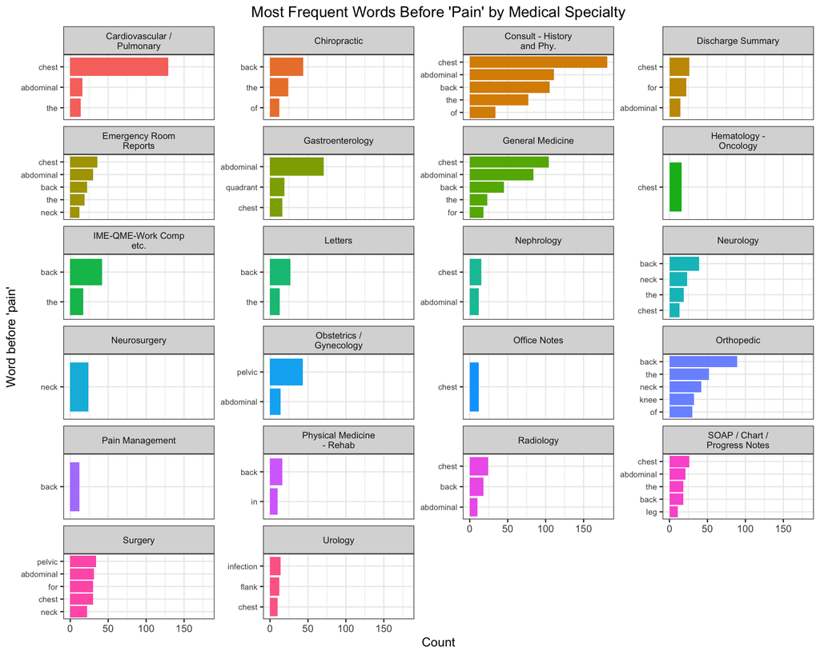

```r
plt1 <- mt_samples %>%
  unnest_tokens(bigram, transcription, token = "ngrams", n = 2) %>%
  separate(bigram, c("word1", "word2"), sep = " ") %>%
  filter(!grepl("^[0-9]+$", word1) & !grepl("^[0-9]+$", word2)) %>%
  filter(word2 == "pain") %>%
  group_by(medical_specialty) %>%
  count(word1, word2, sort = T) %>%
  top_n(5, n) %>%
  filter(n >= 10) %>%
  arrange(medical_specialty, desc(n)) %>%
  ungroup()

plt1 %>%
  ggplot(aes(x = reorder_within(word1, n, medical_specialty), y = n, fill = medical_specialty)) +
  geom_col(show.legend = FALSE) +
  scale_x_reordered() +
  facet_wrap(~ medical_specialty, scales = "free_y", ncol = 4, labeller = labeller(medical_specialty = label_wrap_gen(width = 18))) +
  coord_flip() +
  labs(
    x = "Word before 'pain'",
    y = "Count",
    title = "Most Frequent Words Before 'Pain' by Medical Specialty"
  ) +
  theme_bw() +
  theme(
    strip.text = element_text(size = 8),
    axis.text.y = element_text(size = 7),
    plot.title = element_text(hjust = 0.5)
  )
```

This plot explores the most frequent words appearing before “pain” across different medical specialties. (Records with fewer than 10 counts were removed for clarity.) From the visualization, we can see that “chest pain” is the most commonly described condition, especially in Consult/History and Cardiovascular/Pulmonary specialties, which aligns with their clinical focus on heart and respiratory issues. In contrast, “neck pain” appears mainly in Surgery, Orthopedic, and Neurology-related specialties, reflecting their emphasis on nerve-related problems. Overall, the chart highlights how different types of pain are emphasized across specialties, suggesting that certain pain locations are more prevalent or clinically relevant in specific medical domains.